# ENEM 2018 Studies (In construction)

This is an initial study about Item Theory Response (IRT) and regression models. The main objective of this work is to study the social measures that have an impact on students’ proficiency considering the Brazilian High School Exam (Exame Nacional do Ensino Médio - ENEM) in 2018.

# Item Theory Response

## Installation of packages and data clean for IRT

Installation of the packages to clean and extract knowledge from ENEM dataset.

```r
library(dplyr)
library(data.table)
library(tidyr)
library(stringr)
library(splitstackshape)
library(mirt)
library(GGally)
```

Due the size of the raw data we read the data from a local directory. To illustrate the analysis built here, we use only the first 100k individuals. This will be modefied for all students in other analysis.

```r
setwd("F:/microdados/DADOS")
```

```
The working directory was changed to F:/microdados/DADOS inside a notebook chunk. The working directory will be reset when the chunk is finished running. Use the knitr root.dir option in the setup chunk to change the working directory for notebook chunks.
```

```r
memory.limit(24576)
```

```
[1] 24576
```

```r
dat <- data.table::fread(input='enem2018.csv',
                         integer64='character',
                         skip=0,  #Ler do inicio
                         nrows=100000,
                         na.strings = "",
                         showProgress = TRUE)
```

The construction of IRT model is made from four test that compose the exam (CN - Ciencias e Natureza, CH - Ciencias Humanas, Linguagens e Codigos, MT - Matematica e suas Tecnologias which indicate Sciences and Nature, Sciences and Humans, Languages, and Codes, and Mathematic and its Technology, respectively). For this, We build the answers given by students and answer key datasets (`ans` and `gab`, respectively) droping missing values for all items in each test.

```r
ans <- dat %>% select(TX_RESPOSTAS_CN, TX_RESPOSTAS_CH,
                      TX_RESPOSTAS_LC, TX_RESPOSTAS_MT)
gab <- dat %>% select(TX_GABARITO_CN, TX_GABARITO_CH,
                      TX_GABARITO_LC, TX_GABARITO_MT)
ans <- ans %>% drop_na()
gab <- gab %>% drop_na()
```

The number of questions is computed. Also, the answers given by the students for each test are stored in four datasets as can be seen below. Similarly is made with the answers key.

```r
numb_question <- gab[1, ] %>% str_length()
names_cn <- paste('Q', seq_len(numb_question[1]), sep = '')
names_ch <- paste('Q', seq_len(numb_question[2]), sep = '')
names_lc <- paste('Q', seq_len(numb_question[3]), sep = '')
names_mt <- paste('Q', seq_len(numb_question[4]), sep = '')
ans_cn <-  ans[, 1] %>%
  cSplit('TX_RESPOSTAS_CN', sep = '', stripWhite = FALSE)
ans_ch <-  ans[, 2] %>%
  cSplit('TX_RESPOSTAS_CH', sep = '', stripWhite = FALSE)
ans_lc <-  ans[, 3] %>%
  cSplit('TX_RESPOSTAS_LC', sep = '', stripWhite = FALSE)
ans_mt <-  ans[, 4] %>%
  cSplit('TX_RESPOSTAS_MT', sep = '', stripWhite = FALSE)
gab_cn <-  gab[, 1] %>%
  cSplit('TX_GABARITO_CN', sep = '', stripWhite = FALSE)
gab_ch <-  gab[, 2] %>%
  cSplit('TX_GABARITO_CH', sep = '', stripWhite = FALSE)
gab_lc <-  gab[, 3] %>%
  cSplit('TX_GABARITO_LC', sep = '', stripWhite = FALSE)
gab_mt <-  gab[, 4] %>%
  cSplit('TX_GABARITO_MT', sep = '', stripWhite = FALSE)
```

Next, we renamed the answers and answers key for `Q.`, where `.` indicates the question number.

```r
names(ans_ch) <- names_cn
names(ans_cn) <- names_ch
names(ans_lc) <- names_lc
names(ans_mt) <- names_mt
names(gab_ch) <- names_cn
names(gab_cn) <- names_ch
names(gab_lc) <- names_lc
```

To apply the IRT model with three parameters we define as one the correct answers and zero otherwise.

```r
#Correction of questions
cor_cn <- + (as.matrix(ans_cn) == as.matrix(gab_cn))
cor_ch <- + (as.matrix(ans_ch) == as.matrix(gab_ch))
cor_lc <- + (as.matrix(ans_lc) == as.matrix(gab_lc))
cor_mt <- + (as.matrix(ans_mt) == as.matrix(gab_mt))
```

## IRT Modeling from Three Parameters Model

From `mirt` function the Multivariate Item Response Theory (MIRT) was applied. We highlight that the problem is univariate, i.e. there is only one population in study.

```r
model_cn <- mirt(cor_cn, 1, type = '3PL')
```

```
Iteration: 1, Log-Lik: -1863789.207, Max-Change: 0.34687
Iteration: 2, Log-Lik: -1854744.863, Max-Change: 0.13563
Iteration: 3, Log-Lik: -1851208.257, Max-Change: 0.10557
Iteration: 4, Log-Lik: -1848970.303, Max-Change: 0.05312
Iteration: 6, Log-Lik: -1847975.922, Max-Change: 0.01881
Iteration: 8, Log-Lik: -1847884.414, Max-Change: 0.00600
Iteration: 9, Log-Lik: -1847878.572, Max-Change: 0.00348
Iteration: 11, Log-Lik: -1847876.306, Max-Change: 0.00118
Iteration: 12, Log-Lik: -1847876.133, Max-Change: 0.00071
Iteration: 14, Log-Lik: -1847876.049, Max-Change: 0.00022
Iteration: 15, Log-Lik: -1847876.043, Max-Change: 0.00015
Iteration: 16, Log-Lik: -1847876.037, Max-Change: 0.00006
```

```r
model_ch <- mirt(cor_ch, 1, type = '3PL')
```

[output not shown]

```r
model_mt <- mirt(cor_mt, 1, type = '3PL')
```

```
Iteration: 1, Log-Lik: -1838457.584, Max-Change: 0.43471
Iteration: 3, Log-Lik: -1823280.926, Max-Change: 0.08799
Iteration: 4, Log-Lik: -1822037.093, Max-Change: 0.04325
Iteration: 6, Log-Lik: -1821519.331, Max-Change: 0.01617
Iteration: 7, Log-Lik: -1821481.784, Max-Change: 0.00904
Iteration: 8, Log-Lik: -1821470.670, Max-Change: 0.00499
Iteration: 9, Log-Lik: -1821467.389, Max-Change: 0.00284
Iteration: 10, Log-Lik: -1821466.203, Max-Change: 0.00125
Iteration: 11, Log-Lik: -1821466.010, Max-Change: 0.00070
Iteration: 12, Log-Lik: -1821465.946, Max-Change: 0.00049
Iteration: 13, Log-Lik: -1821465.933, Max-Change: 0.00029
Iteration: 15, Log-Lik: -1821465.920, Max-Change: 0.00009
```

Coefficients and performance are displayed below.

```r
#Coefficients
coef_cn <- coef(model_cn, simplify = TRUE, IRTpars = TRUE)
coef_ch <- coef(model_ch, simplify = TRUE, IRTpars = TRUE)
coef_lc <- coef(model_lc, simplify = TRUE, IRTpars = TRUE)
coef_mt <- coef(model_mt, simplify = TRUE, IRTpars = TRUE)
#M2 performance measure
M2(model_cn)
```

|  | M2 | df | p | RMSEA | RMSEA_5 | RMSEA_95 | SRMSR | TLI | CFI |
| --- | --- | --- | --- | --- | --- | --- | --- | --- | --- |
| stats | 51579.48 | 945 | 0 | 0.02710437 | 0.0269054 | 0.02730349 | 0.0265551 | 0.7037644 | 0.7172297 |

```r
M2(model_ch)
```

|  | M2 | df | p | RMSEA | RMSEA_5 | RMSEA_95 | SRMSR | TLI | CFI |
| --- | --- | --- | --- | --- | --- | --- | --- | --- | --- |
| stats | 158251.9 | 945 | 0 | 0.04777383 | 0.04757523 | 0.04797207 | 0.04335033 | 0.8105813 | 0.8191912 |

```r
M2(model_lc)
```

|  | M2 | df | p | RMSEA | RMSEA_5 | RMSEA_95 | SRMSR | TLI | CFI |
| --- | --- | --- | --- | --- | --- | --- | --- | --- | --- |
| stats | 353037.5 | 1175 | 0 | 0.06407662 | 0.06389844 | 0.0642541 | 0.06153831 | 0.6480307 | 0.6623968 |

```r
M2(model_mt)
```

|  | M2 | df | p | RMSEA | RMSEA_5 | RMSEA_95 | SRMSR | TLI | CFI |
| --- | --- | --- | --- | --- | --- | --- | --- | --- | --- |
| stats | 69304.51 | 945 | 0 | 0.03149311 | 0.03129432 | 0.03169193 | 0.0305916 | 0.6773698 | 0.6920348 |

## Proficiency and Item Study

```r
prof_cn <- fscores(model_cn, method = 'EAP')
prof_ch <- fscores(model_ch, method = 'EAP')
prof_lc <- fscores(model_lc, method = 'EAP')
prof_mt <- fscores(model_mt, method = 'EAP')
```

Based on the ENEM IRT approach, we resize the scores. The adopted range is (500, 100); the more or less distant from 500, the student will be considered more or less proficient, respectively.

```r
scale_change <- function(value, mu, sigma){
  sigma * value + mu
}
prof_cn <- apply(prof_cn, 1, function(x) scale_change(x, 500, 100) )
prof_lc <- apply(prof_lc, 1, function(x) scale_change(x, 500, 100) )
prof_mt <- apply(prof_mt, 1, function(x) scale_change(x, 500, 100) )
prof <- data.frame(CN = prof_cn, CH = prof_ch, LC = prof_lc, MT = prof_mt)
```

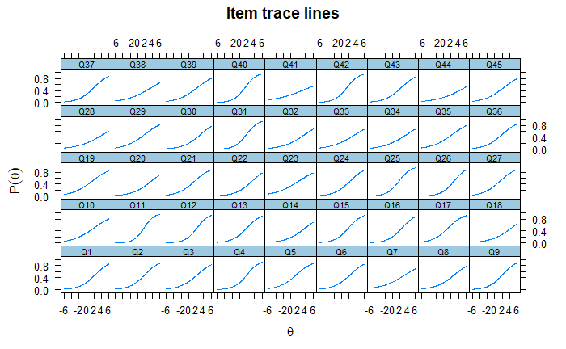

```r
plot(model_cn, type = 'trace')
```

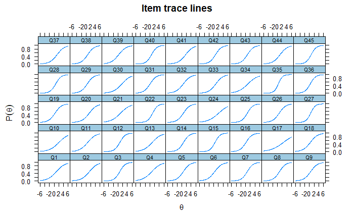

```r
plot(model_ch, type = 'trace')
```

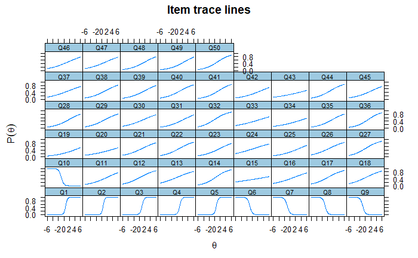

```r
plot(model_lc, type = 'trace')
```

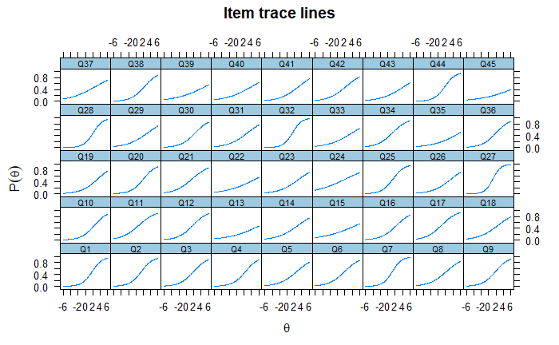

```r
plot(model_mt, type = 'trace')
```

It is fundamental the quantitaty of information stored by each item. The figures show the item information curve. Item information functions tend to look bell-shaped similar to the normal distribution. Highly discriminating items have tall, narrow information functions; they contribute greatly but over a narrow range. Less discriminating items provide less information but over a wider range. In this case, e.g. considering the CN test the items Q42, Q40, Q31, and Q25 are considered highly informative, but Q44, Q38, Q28, and Q32 have low information.

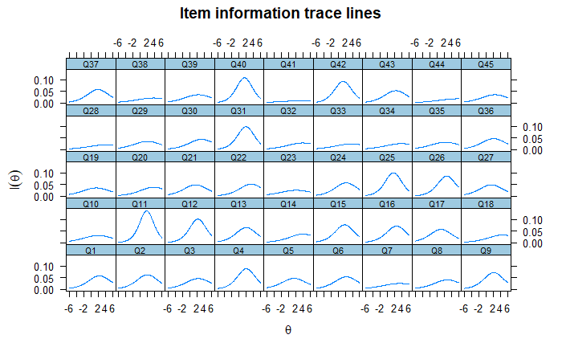

```r
plot(model_cn, type = 'infotrace')
```

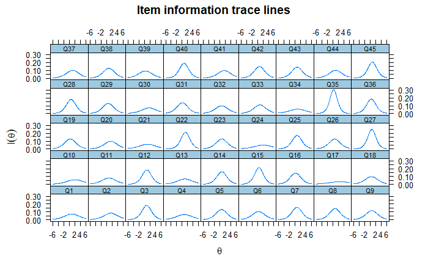

```r
plot(model_ch, type = 'infotrace')
```

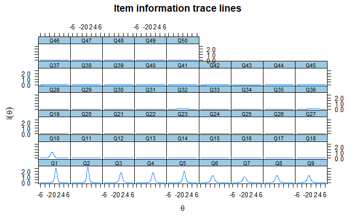

```r
plot(model_lc, type = 'infotrace')
```

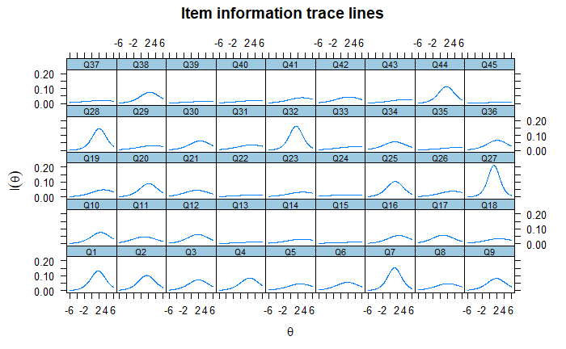

```r
plot(model_mt, type = 'infotrace')
```

Other way to calculate the information of each item is displayed below. Then, we calculate the information for each item from some theta values.

```r
theta <- matrix(seq(-4, 4, by = .1))
seq_cn <- matrix(seq_len(length(names_cn)), ncol = 1)
seq_ch <- matrix(seq_len(length(names_ch)), ncol = 1)
seq_mt <- matrix(seq_len(length(names_mt)), ncol = 1)
extr_item_cn <- lapply(seq_cn, function(x) extract.item(model_cn, x))
extr_item_ch <- lapply(seq_ch, function(x) extract.item(model_ch, x))
extr_item_lc <- lapply(seq_lc, function(x) extract.item(model_lc, x))
info_item_cn <- lapply(extr_item_cn, function(x) iteminfo(x, theta))
info_item_ch <- lapply(extr_item_ch, function(x) iteminfo(x, theta))
info_item_lc <- lapply(extr_item_lc, function(x) iteminfo(x, theta))
info_item_mt <- lapply(extr_item_mt, function(x) iteminfo(x, theta))
```

The `b` parameter indicates the difficulty of item. The first most hard question for each test are: (i) CN - 44, 41, 18, 28, and 14; (ii) CH - 17, 24, 10, 30, and 41; (iii) LC - 43, 19, 20, 15, and 34; (iv) MT - 45, 13, 35, 39, and 15.

```r
#The items are sorted from difficulty parameters b
dif_cn <- data.frame(question = seq_cn, coef_cn$items) %>% arrange(desc(b))
dif_ch <- data.frame(question = seq_ch, coef_ch$items) %>% arrange(desc(b))
dif_lc <- data.frame(question = seq_lc, coef_lc$items) %>% arrange(desc(b))
dif_mt <- data.frame(question = seq_mt, coef_mt$items) %>% arrange(desc(b))
dif_cn
```

| question | a | b | g | u |
| --- | --- | --- | --- | --- |
| 44 | 0.2736131 | 5.722439 | 0 | 1 |
| 41 | 0.2102391 | 5.064263 | 0 | 1 |
| 18 | 0.3646191 | 4.550572 | 0 | 1 |
| 28 | 0.2935206 | 4.496155 | 0 | 1 |
| 14 | 0.3848404 | 3.959543 | 0 | 1 |
| 32 | 0.3396802 | 3.879636 | 0 | 1 |
| 34 | 0.3223968 | 3.855409 | 0 | 1 |
| 33 | 0.3128808 | 3.754086 | 0 | 1 |
| 38 | 0.2976220 | 3.704189 | 0 | 1 |
| 20 | 0.3932157 | 3.654624 | 0 | 1 |

[output cut: 35 more lines]

```r
dif_ch
```

| question | a | b | g | u |
| --- | --- | --- | --- | --- |
| 17 | 0.3712957 | 2.5829667 | 0 | 1 |
| 24 | 0.4448539 | 2.1463865 | 0 | 1 |
| 10 | 0.4909497 | 2.0608289 | 0 | 1 |
| 30 | 0.5379026 | 1.6597434 | 0 | 1 |
| 41 | 0.6236978 | 1.6524706 | 0 | 1 |
| 2 | 0.5823677 | 1.4353212 | 0 | 1 |
| 20 | 0.6311380 | 1.3672536 | 0 | 1 |
| 37 | 0.6347616 | 1.2085651 | 0 | 1 |
| 22 | 0.9226570 | 1.1758278 | 0 | 1 |
| 44 | 0.6361197 | 1.1042386 | 0 | 1 |

[output cut: 35 more lines]

```r
dif_lc
```

| question | a | b | g | u |
| --- | --- | --- | --- | --- |
| 43 | 0.1654961 | 5.805041922 | 0 | 1 |
| 19 | 0.2442078 | 5.330344285 | 0 | 1 |
| 20 | 0.1907692 | 5.269432985 | 0 | 1 |
| 15 | 0.1103563 | 5.097312549 | 0 | 1 |
| 34 | 0.2003837 | 4.710480546 | 0 | 1 |
| 25 | 0.2660041 | 3.486116163 | 0 | 1 |
| 42 | 0.2599288 | 3.218596438 | 0 | 1 |
| 33 | 0.1938458 | 2.859542763 | 0 | 1 |
| 49 | 0.3518455 | 2.653685693 | 0 | 1 |
| 31 | 0.3170719 | 2.429664229 | 0 | 1 |

[output cut: 40 more lines]

```r
dif_mt
```

| question | a | b | g | u |
| --- | --- | --- | --- | --- |
| 45 | 0.2157861 | 7.9071391 | 0 | 1 |
| 13 | 0.2399718 | 6.4295978 | 0 | 1 |
| 35 | 0.2826795 | 5.8861728 | 0 | 1 |
| 39 | 0.2471891 | 5.1750045 | 0 | 1 |
| 15 | 0.2142830 | 5.1554684 | 0 | 1 |
| 22 | 0.2516305 | 5.1249196 | 0 | 1 |
| 43 | 0.3246423 | 4.4304166 | 0 | 1 |
| 40 | 0.2802242 | 4.0920761 | 0 | 1 |
| 33 | 0.3086251 | 4.0558499 | 0 | 1 |
| 26 | 0.3949155 | 3.5372582 | 0 | 1 |

[output cut: 35 more lines]

# Response variable study

As mentioned we desire to evaluate the main variables that have influence in proficiency exam. For this, we analysis the correlation between the four variables, this study is important to define the statistical paradigm selected. Four regression models separately or a multivariate regression model.

## Correlation Analysis

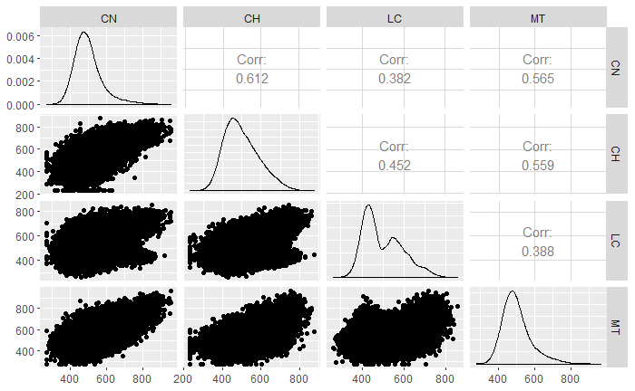

```r
prof %>% ggpairs()
```

```r
cor(prof)
```

[output not shown]